# Introduction to Linear Regression

Data Science for Biologists, Spring 2020

Nicholas Paterna

## Instructions

Standard grading criteria apply, except there is no “answer style” - just write out answers normally! Note the following:

- $\alpha = 0.05$
- When adding regression lines as plot subtitles, don’t worry about writing $\epsilon$
- Do not remove insignificant predictors from your regression line formula when reporting it (this is just a question I get a lot)

This assignment will use an external dataset from a field experiment studying the diversity of [Chinese Rowan](https://en.wikipedia.org/wiki/Rowan) trees. Researchers randomly sampled and recorded characteristics of leaves from three different species in the *Sorbus* genus. They recorded the following measurements for each tree (don’t worry about units)

For this assignment, you will examine how various predictors may explain variation in *respiratory rate.*

```r
# rowan trees, no relation :)
rowan <- read_csv("https://raw.githubusercontent.com/sjspielman/datascience_for_biologists/master/data/rowan_trees.csv")
dplyr::glimpse(rowan)
```

```
## Observations: 300
## Variables: 5
## $ species          <chr> "microphylla", "microphylla", "microphylla", "microp…
## $ altitude         <dbl> 457, 644, 497, 412, 460, 467, 394, 474, 475, 397, 51…
## $ respiratory_rate <dbl> 0.266, 0.272, 0.231, 0.108, 0.216, 0.291, 0.244, 0.0…
## $ leaf_len         <dbl> 8.7, 9.5, 7.9, 9.5, 10.1, 9.1, 7.2, 9.7, 8.6, 9.3, 8…
## $ nesting_birds    <chr> "n", "n", "y", "y", "n", "y", "n", "n", "n", "y", "n…
```

### Question 1

> Background for this completing question is under the header “Simple linear regression: Single numeric predictor” in the linear regression tutorial

Construct a linear model that examines how *altitude* might explain variation in *respiratory rate*. Take the following steps to do so (code as you go through the steps!)

Make a quick scatterplot to make sure the “linear relationship” assumption is met for this data. Be sure to have your predictor and response on the correct axis!:

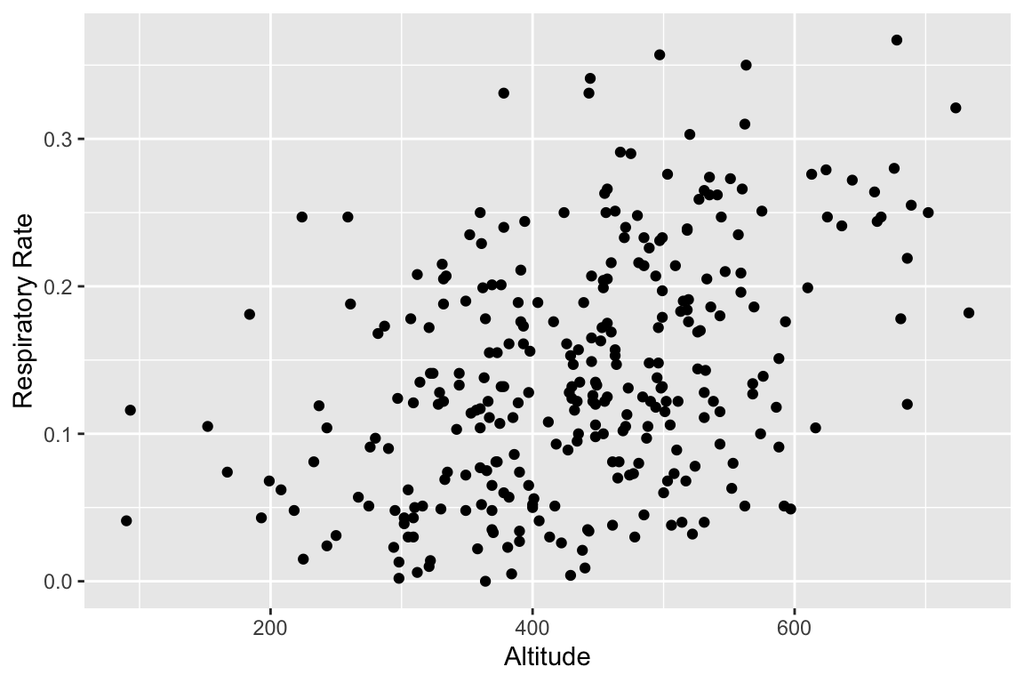

```r
### figure to check linearity goes here.
### no need for fancy, can keep labels as is, etc.
ggplot(rowan, aes(x = altitude, y = respiratory_rate)) +
  geom_point() +
  labs(x = "Altitude", y = "Respiratory Rate")
```

Now that you have confirmed the relationship is linear (hint: it is linear), build your linear model. *BEFORE you examine its output*, evaluate whether the model residuals were normally distributed:

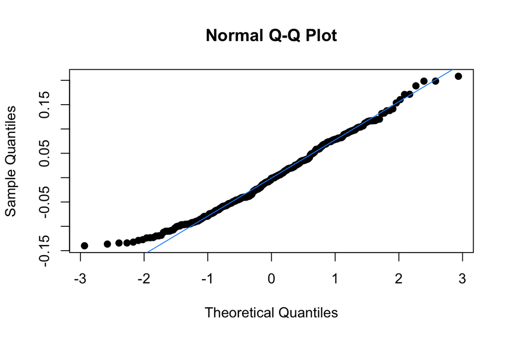

```r
### build model and check normal residuals
### do not look at the model summary yet!
fit <- lm(formula = respiratory_rate ~ altitude, data = rowan)
  #Always use y ~ x for formula!!!

augment(fit, rowan) -> augmented_fit
  #We use this function from broom to create a tibble with the residuals

qqnorm(augmented_fit$.resid, pch = 19)
qqline(augmented_fit$.resid, col = "dodgerblue")
```

```r
  #Here the pch is the spacing of the points, we are plotting the residual values from the augmented fit.
 #Using base R to create a linear regression with the residual values vs. the experimental observations.
```

Now that you have confirmed the residuals are roughly normally distributed (hint: they are), examine the output from your linear model. In the space below the code chunk, discuss in *bullet form* (1-2 sentences each): a) Provide an interpretation of the intercept, b) Provide an interpretation of the altitude coefficient, c) Provide an interpretation of the $R^2$ value (those dollar signs signify “math mode” - see the HTML output!), and finally d) Conclude whether altitude is a strong or weak predictor of respiratory rate, consider “biological significance” (effect size!) as well as statistical significance.

```r
## examine model output here
summary(fit)
```

```
##
## Call:
## lm(formula = respiratory_rate ~ altitude, data = rowan)
##
## Residuals:
##      Min       1Q   Median       3Q      Max
## -0.13997 -0.05365 -0.00145  0.05206  0.20827
##
## Coefficients:
##              Estimate Std. Error t value Pr(>|t|)
## (Intercept) 8.386e-03  1.702e-02   0.493    0.622
## altitude    3.025e-04  3.778e-05   8.007 2.66e-14 ***
## ---
## Signif. codes:  0 '***' 0.001 '**' 0.01 '*' 0.05 '.' 0.1 ' ' 1
##
## Residual standard error: 0.07333 on 298 degrees of freedom
## Multiple R-squared:  0.177,  Adjusted R-squared:  0.1743
## F-statistic: 64.11 on 1 and 298 DF,  p-value: 2.66e-14
```

- **Intercept Interpretation**
  - We expect that a tree’s *respiratory rate* will be 8.386e-03 when the **altitude is 0**. However, p is not significant at p = 0.622 so we actually have no evidence that intercept differs from 0.
- **Altitude Coefficient Interpretation**
  - For every unit increase in altitude, we expect respiratory rate increase by 3.025e-04, this is highly significant because our p-value is so small for this measurment (p = 2.66e-14).
- **$R^2$ Interpretation**
  - $R^2 = 0.1743$ which means that approx. 17% of variation in respiratory rate is explained by our model, which included only altitude predictir. This is highly significant as the corresponding p-value is so small (p = 2.66e-14).
  - From this, approximately 83% of these respiratory rate cannot be explained by this model.
- **Model Conclusion**
  - Y = 3.025e-04X + 8.386e-03

Finally, make a stylish scatterplot of your findings. Your scatterplot should:

- Use your favorite ggplot theme and colors (it’s allowed to like the default!)
- Clearly show the regression line and its 95% confidence interval
- Include a meaningful title, along with a subtitle that is the fitted model itself, as well as other nice labels
- Include a well-placed annotation that gives the model’s $R^2$

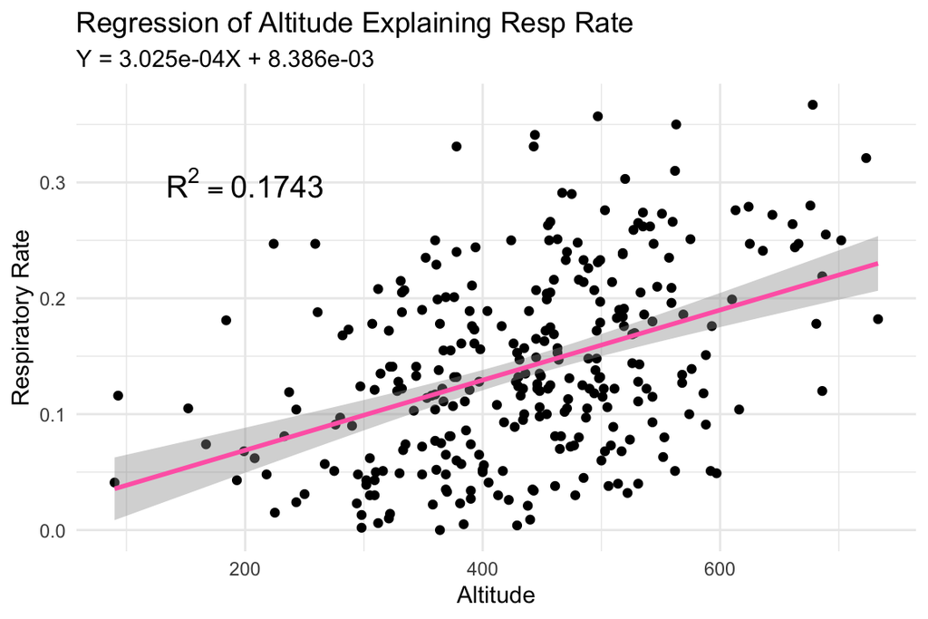

```r
### stylish plot goes here
ggplot(rowan, aes(x = altitude, y = respiratory_rate)) +
  geom_point() +
  labs(title = "Regression of Altitude Explaining Resp Rate",
       subtitle = "Y = 3.025e-04X + 8.386e-03",
       x = "Altitude", y = "Respiratory Rate") +
  geom_smooth(method = "lm", color = "hotpink") +
  #Default confidence interval (shaded area) is 95%
  annotate("text", label = "R^2 == 0.1743",
           x = 200, y = 0.3,
           size = 5,
           parse = TRUE) +
  theme_minimal()
```

### Question 2

> Background for this completing question is under the header “Simple ANOVA: Single categorical predictor” in the linear regression tutorial

Construct a linear model that examines how *species* might explain variation in *respiratory rate*. Take the following steps to do so (code as you go through the steps!)

Make a quick plot (use `geom_point()`, seriously, not even a jitter!!) to make sure the “equal variance” assumption is met for this data:

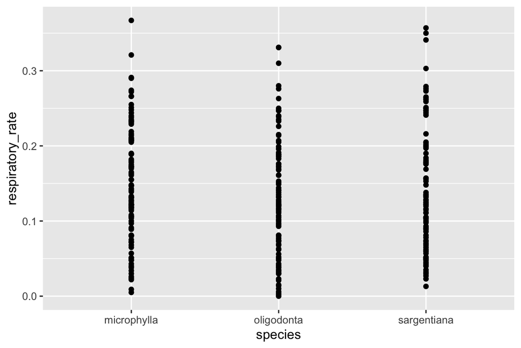

```r
### figure to check assumption goes here.
### no need for fancy, can keep labels as is, etc.
ggplot(rowan, aes(x = species, y = respiratory_rate)) +
  geom_point()
```

```r
#This essentially shows us the variation between the resp rate over the three species, it is clear that they are fairly similar.
```

Now that you have confirmed the variance is equal across groups (hint: it is), build your linear model. *BEFORE you examine its output*, evaluate whether the model residuals were normally distributed:

[figure not shown]

```r
### build model and check normal residuals
### do not look at the model summary yet!

fit_2 <- lm(formula = respiratory_rate ~ species, data = rowan)
  #Always use y ~ x for formula!!!

augment(fit, rowan) -> augmented_fit2
  #We use this function from broom to create a tibble with the residuals

qqnorm(augmented_fit2$.resid, pch = 19)
qqline(augmented_fit2$.resid, col = "goldenrod")
```

```r
  #Here the pch is the spacing of the points, we are plotting the residual values from the augmented fit.
 #Using base R to create a linear regression with the residual values vs. the experimental observations.
```

Now that you have confirmed the residuals are roughly normally distributed (hint: they are), examine the output from your linear model. In the space below the code chunk, discuss in *bullet form* (1-2 sentences each): a) Provide an interpretation of the intercept, b) Provide an interpretation of the species coefficient, c) Provide an interpretation of the $R^2$ value, and finally d) Conclude whether species is a strong or weak predictor of respiratory rate, consider “biological significance” (effect size!) as well as statistical significance.

```r
## examine model output here
summary(fit_2)
```

```
##
## Call:
## lm(formula = respiratory_rate ~ species, data = rowan)
##
## Residuals:
##       Min        1Q    Median        3Q       Max
## -0.143680 -0.065087 -0.009765  0.058320  0.218320
##
## Coefficients:
##                     Estimate Std. Error t value Pr(>|t|)
## (Intercept)         0.148680   0.008059  18.450   <2e-16 ***
## speciesoligodonta  -0.018830   0.011397  -1.652   0.0995 .
## speciessargentiana -0.006180   0.011397  -0.542   0.5880
## ---
## Signif. codes:  0 '***' 0.001 '**' 0.01 '*' 0.05 '.' 0.1 ' ' 1
##
## Residual standard error: 0.08059 on 297 degrees of freedom
## Multiple R-squared:  0.009463,   Adjusted R-squared:  0.002792
## F-statistic: 1.419 on 2 and 297 DF,  p-value: 0.2437
```

```r
unique(rowan$species)
```

```
## [1] "microphylla" "oligodonta"  "sargentiana"
```

```r
#This shows us the unique variables in the species col so we can determine which of these was the "baseline" for our model
```

- **Intercept Interpretation**
  - For microphylla trees we expect a mean respiratory rate of 0.148680, this is highly significant as our p-value is so small (p < 2e-16).
- **Species Coefficient Interpretation**
  - We expect on average, *oligodonta* trees have a respiratory rate that is 0.018830 lower than microphylla. However, this is not significant due to the high p-value (p = 0.0995).
    - We expect on average, *argentiana* trees have a respiratory rate that is 0.006180 lower than microphylla. However, this is not significant due to the high p-value (p = 0.5880).
- **$R^2$ Interpretation**
  - Our $R^2 = 0.002792$ which is not NOT SIGNIFICANT because the p-value is so large (p = 0.2437). No evidence that any variation is explained, 100% of variation in respiratory rate is unexplained by model.
- **Model Conclusion**
  - Entirely uninformative model, species does NOT predict or explain the respiratory rate of the trees.
  - Y = -0.018830X1 + -0.006180X2 + 0.148680

Finally, make a stylish figure of your findings, choosing your own geom!

- Use your favorite ggplot theme and colors (it’s allowed to like the default!)
- If your geom does not already show the center of each group (i.e. like a boxplot), be sure to add the means in with `stat_summary()`
- Include a meaningful title, along with a subtitle that is the fitted model itself, as well as other nice labels
- Include a well-placed annotation that gives the model’s $R^2$

```
## No summary function supplied, defaulting to `mean_se()
```

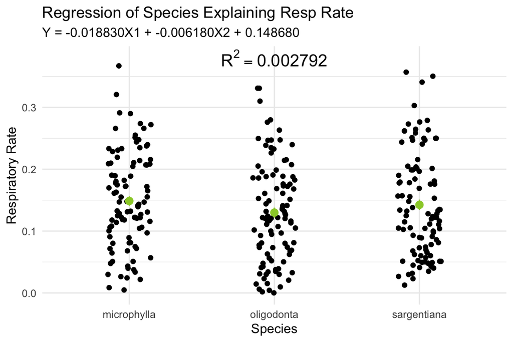

```r
### stylish plot goes here
ggplot(rowan, aes(x = species, y = respiratory_rate)) +
  geom_jitter(width = 0.15) +
  stat_summary(color = "yellowgreen") +
  #Adds a point into the plot that shows the std error for all of the points
  annotate("text", label = "R^2 == 0.002792",
           x = 2, y = 0.38,
           size = 5,
           parse = TRUE) +
  labs(title = "Regression of Species Explaining Resp Rate",
       subtitle = "Y = -0.018830X1 + -0.006180X2 + 0.148680",
       x = "Species", y = "Respiratory Rate") +
  theme_minimal()
```

### Question 3

> Background for this completing question is under the header “LM with numeric and categorical predictors” in the linear regression tutorial

Construct a linear model that examines how BOTH *species* and *leaf_len* as independent effects might explain variation in *respiratory rate*. Again, take the following steps one by one:

Since we already checked assumptions for `species` in the last question, make an appropriate plot to check the linearity assumption for `leaf_len`:

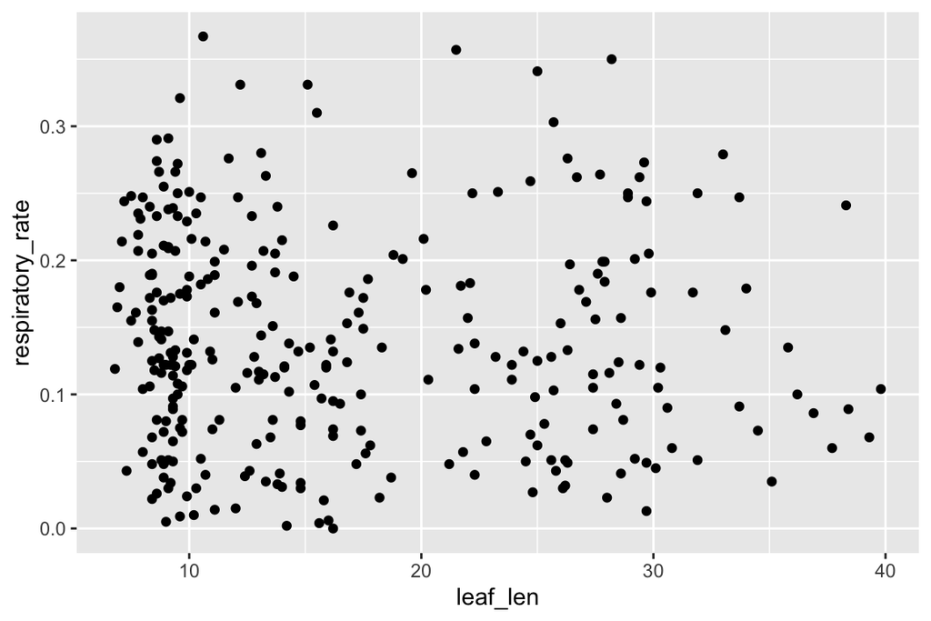

```r
### figure to check assumption goes here.
### no need for fancy, can keep labels as is, etc.
ggplot(rowan, aes(x = leaf_len, y = respiratory_rate)) +
  geom_point()
```

Build your linear model, and evaluate whether the model residuals were normally distributed:

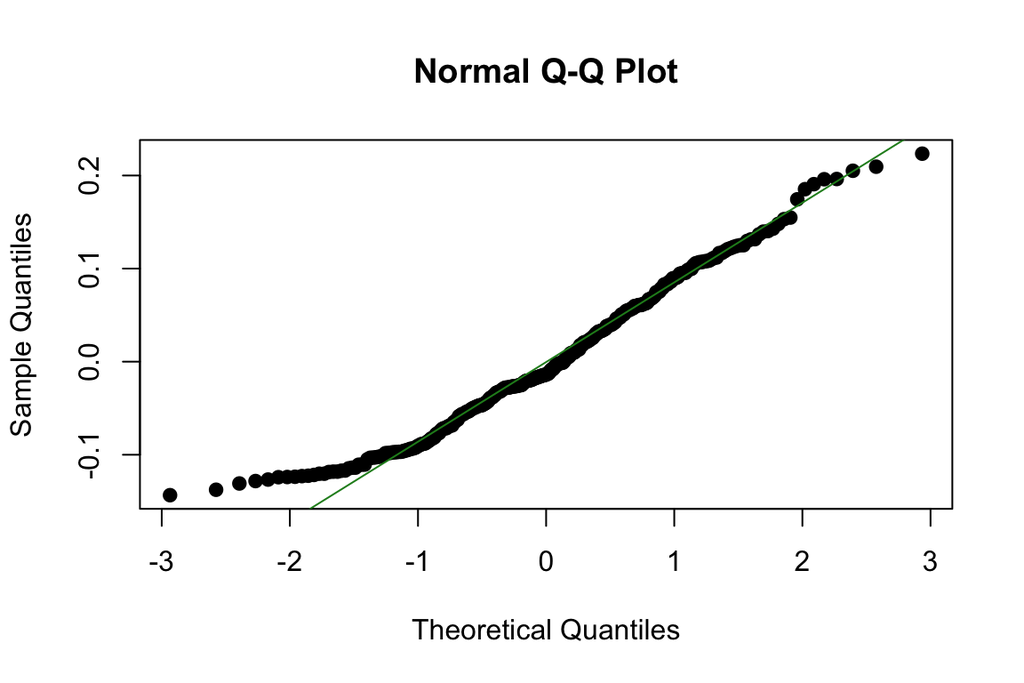

```r
### build model and check normal residuals
### do not look at the model summary yet!
fit_3 <- lm(respiratory_rate ~ species + leaf_len, data = rowan)

augment(fit_3, rowan) -> augmented_fit3
  #We use this function from broom to create a tibble with the residuals

qqnorm(augmented_fit3$.resid, pch = 19)
qqline(augmented_fit3$.resid, col = "forestgreen")
```

```r
  #Here the pch is the spacing of the points, we are plotting the residual values from the augmented fit.
 #Using base R to create a linear regression with the residual values vs. the experimental observations.
```

```r
## examine model output here
summary(fit_3)
```

```
##
## Call:
## lm(formula = respiratory_rate ~ species + leaf_len, data = rowan)
##
## Residuals:
##      Min       1Q   Median       3Q      Max
## -0.14344 -0.05814 -0.01373  0.05732  0.22345
##
## Coefficients:
##                     Estimate Std. Error t value Pr(>|t|)
## (Intercept)         0.175923   0.015300  11.498   <2e-16 ***
## speciesoligodonta  -0.003898   0.013396  -0.291   0.7713
## speciessargentiana  0.050740   0.029495   1.720   0.0864 .
## leaf_len           -0.003054   0.001461  -2.090   0.0375 *
## ---
## Signif. codes:  0 '***' 0.001 '**' 0.01 '*' 0.05 '.' 0.1 ' ' 1
##
## Residual standard error: 0.08013 on 296 degrees of freedom
## Multiple R-squared:  0.02387,    Adjusted R-squared:  0.01398
## F-statistic: 2.413 on 3 and 296 DF,  p-value: 0.06687
```

Finally, make a stylish scatterplot of your findings:

- Use your favorite ggplot theme and colors (it’s allowed to like the default!)
- Make sure to show a regression lines for EACH species. **NOTICE in theses lines** how they are consistent with your conclusions about species being a significant predictor. You do not have to write anything, just notice!
- Include a meaningful title, along with a subtitle that is the fitted model itself, as well as other nice labels
- Include a well-placed annotation that gives the model’s $R^2$

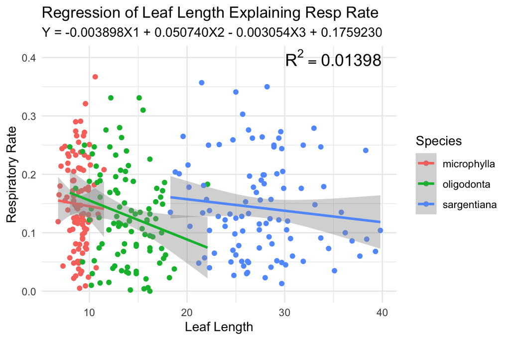

```r
### stylish plot goes here
ggplot(rowan, aes(x = leaf_len, y = respiratory_rate, color = species)) +
  geom_point() +
  geom_smooth(method = "lm") +
  labs(title = "Regression of Leaf Length Explaining Resp Rate",
       subtitle = "Y = -0.003898X1 + 0.050740X2 - 0.003054X3 + 0.1759230",
       x = "Leaf Length", y = "Respiratory Rate", color = "Species") +
  annotate("text", label = "R^2 == 0.01398",
           x = 35, y = 0.4,
           size = 5,
           parse = TRUE) +
  theme_minimal()
```

```r
#The overlapping of the conf intervals shows that this model is poor.
```